# **‘Justice For Who?’**

This analysis supports a data-driven examination of inequalities throughout the justice system in Fresno, California. Data and code can be found [here](https://github.com/reisthebault/unequal_from_birth). Find the story here, part of a larger project called Unequal From Birth, which was produced by a team of reporters at UC Berkeley’s Graduate School of Journalism. Find more information on the project here.

### Setting up

Loading packages to read, manipulate and plot our data, and download data from the Census Bureau. For more information on Census API keys, see [here](https://www.census.gov/data/developers/guidance/api-user-guide.html).

```r
# loading required packages
library(readr)
library(dplyr)
library(censusapi)
library(tigris)
library(rgdal)
library(leaflet)
library(mapview)
library(plotly)
library(DT)

# set census api key
Sys.setenv(CENSUS_KEY="YOUR API KEY HERE")
readRenviron("~/.Renviron")
```

## **Looking at traffic stops — who’s pulled over and where**

### Loading the data

The two sets of data we load in here both came from the Fresno Police Department. The locations data gives us longitude/latitude fields for each stop made by the department’s patrol unit. The traffic unit did not keep data in the same way, so we are not able to geocode those stops.

```r
# loading stop data
tstops <- read_csv("trafficStops_fpd_16.csv")

# formatting time
tstops <- tstops %>%
  mutate(CONTACT_TIME = as.POSIXct(CONTACT_TIME, format="%m/%d/%y %H:%M"))

# IDing stops made by the traffic unit and stops made by the patrol unit
tstops_traffic <- tstops %>%
  filter(is.na(EVENT_NUM)) %>%
  mutate(unit="traffic")

tstops_patrol <- anti_join(tstops,tstops_traffic)  %>%
  mutate(unit="patrol") %>%
  unique()

# loading locations of stops made by the patrol unit and fixing dupes
locations <- read_csv("trafficStops_locations_16.csv") %>%
  unique()

# joining the locations data onto tstops
tstops_locations <- inner_join(tstops_patrol,locations, by=c("EVENT_NUM"="EVENT_NO"))
```

### Total stops by race

Right off the bat, we look for disproportionality in each race’s share of stops. Later, we compare these percentages to the city’s driving-age population. Note:‘H’ = hispanic, ‘W’ = white, ‘B’ = black, ‘A’ = asian, ‘O’ = other.

```r
# looking at stops by race
stops_race <- tstops %>%
  group_by(APPARENT_RACE) %>%
  summarise(total_stops=n()) %>%
  arrange(desc(total_stops)) %>%
  mutate(pc_stops = round(total_stops/sum (total_stops)*100,2))

datatable(stops_race, rownames = FALSE, colnames = c("race", "total stops", "percent stops"))
```

| race | total stops | percent stops |
| --- | --- | --- |
| H | 20434 | 50.03 |
| W | 9620 | 23.55 |
| B | 6005 | 14.7 |
| O | 2581 | 6.32 |
| A | 2197 | 5.38 |
|  | 4 | 0.01 |

### Comparing share of traffic stops to share of population

How do those percentages match up to each race’s share of Fresno’s population? Here, we found disproportionality in FPD’s traffic stops.

```r
# making a bar chart for tstops and population

# joining driving age data to stop data
driving_age <- read_csv("drivingAge_fresno.csv")

# renaming variables, spelling out race names

stops_race[1, "APPARENT_RACE"] <- "hispanic"
stops_race[2, "APPARENT_RACE"] <- "white"
stops_race[3, "APPARENT_RACE"] <- "black"
stops_race[4, "APPARENT_RACE"] <- "other"
stops_race[5, "APPARENT_RACE"] <- "asian"

pop_stop <- left_join(driving_age, stops_race, by=c("race"="APPARENT_RACE"))

# setting x axis order
xform2 <- list(categoryorder = "array",
               categoryarray = c("white",
                                 "hispanic",
                                 "black",
                                 "asian"))

pop_stop_chart <-  plot_ly(pop_stop, x = ~race, y = ~pc_drivers, type = 'bar', name = '% of driving-age pop.',
                           marker = list(color = 'rgba(189,189,189,0.5)',
                                         line = list(color = 'rgba(189,189,189,.1)',
                                                     width = .7))) %>%
  add_trace(y = ~pc_stops, name = '% of drivers stopped',
            marker = list(color = 'rgba(37,37,37,0.5)',
                          line = list(color = 'rgba(37,37,37,1)',
                                      width = .7))) %>%
  layout(yaxis = list(title = 'Percent'),
         xaxis = list(title = 'Race'),
         barmode = 'group') %>%
  config(displayModeBar = FALSE) %>%
  layout(xaxis = xform2)


print(pop_stop_chart)

# saving as html page
htmlwidgets :: saveWidget(pop_stop_chart, "pop_stop_chart.html", selfcontained = TRUE, libdir = NULL, background = "white")
```

[interactive chart not shown]

### Loading and processing Census data, tract shapefiles, and police district shapefiles

In order to map where these stops are happening, and how stops compare to tthe city’s demographic makeup, we loaded census tract level demographic data and shapefiles. Then we clipped those to the latest FPD district boundaries so that we see only demographic data from tracts wihtin FPD’s jurisdiction.

```r
# grabbing census tract level demographic data
ct <- getCensus(name = "acs5",
                vintage = 2015,
                vars = c("GEOID",
                         "B01003_001E",
                         "B03002_003E",
                         "B03002_004E",
                         "B03002_012E",
                         "B03002_006E"),
                region = "tract:*",
                regionin = "state:06+county:019")

names(ct) <- c("GEOID", "state", "county", "tract", "total_population","white_population", "black_population", "hispanic_population", "asian_population")

ct <- ct %>%
  mutate(pc_black_population = round(black_population/total_population*100,2),
         pc_white_population = round(white_population/total_population*100,2),
         pc_hispanic_population = round(hispanic_population/total_population*100,2),
         pc_asian_population = round(asian_population/total_population*100,2))


# fixing NaNs
is.nan.data.frame <- function(x)
  do.call(cbind, lapply(x, is.nan))
ct[is.nan(ct)] <- 0

# load TIGER/LINE shapefiles for census tracts in Fresno
tracts_map <- tracts("06", county = "019")


# joining demographic data to tracts shapefile
tracts_merged <- geo_join(tracts_map,ct, "TRACTCE", "tract")


# loading shape files for fresno police department districts
fpdBound_shape <- readOGR("pdbound.shp")


# converting to long/lat projection
fpdBound_ll <- spTransform(fpdBound_shape, CRS('+proj=longlat +datum=NAD83 +no_defs +ellps=GRS80 +towgs84=0,0,0'))

# turning policing districts into lines
fpdBound_lines <- as(fpdBound_ll, "SpatialLinesDataFrame")

# clipping tracts map to police districts so that we're only looking at tracts within fpd jurisdiction
fpd_tracts <- raster::intersect(tracts_merged,fpdBound_ll)
```

### Counting the number of stops, searches and arrests that happened in each census tract

We are interested in three types of incidents: traffic stops in general, stops that resulted in the search of a driver’s vehicle and stops that resulted in arrest. Here, we count the number of times each of those events occurred in each of the city’s census tracts. To do this, we counted points in polygons.

```r
## calculating and mapping total number of stops, searches and arrests in each census tract

# grabbing only long/lat columns and turning each stop into a point
stop_coords <- tstops_locations %>%
  select(LONGT,LAT) %>%
  filter(!is.na(LAT))

# turning stops into spatial points
stop_sp <- SpatialPoints(stop_coords)

# applying same projection to the points as we're using with our map
proj4string(stop_sp) <- "+proj=longlat +datum=NAD83 +no_defs +ellps=GRS80 +towgs84=0,0,0"

# now counting total number of stops in each tract
by_tract <- over(stop_sp, tracts_map)

by_tract <- by_tract %>%
  group_by(GEOID) %>%
  summarise(total_stops=n()) %>%
  mutate(pc_stops = round(total_stops/sum(total_stops)*100,2)) %>%
  mutate(GEOID = as.character(GEOID)) %>%
  filter(!is.na(GEOID))

# calculating the above for searches
search_locations <- tstops_locations %>%
  filter(VEHICLE_SEARCHED=="Y")

# grabbing only long/lat columns and turning each search into a point
search_coords <- search_locations %>%
  select(LONGT,LAT) %>%
  filter(!is.na(LAT))

# turning searches into spatial points
search_sp <- SpatialPoints(search_coords)

# applying same projection to the points as we're using with our map
proj4string(search_sp) <- "+proj=longlat +datum=NAD83 +no_defs +ellps=GRS80 +towgs84=0,0,0"

# now counting total number of stops in each tract
by_tract_search <- over(search_sp, tracts_map)

by_tract_search <- by_tract_search %>%
  group_by(GEOID) %>%
  summarise(total_searches=n()) %>%
  mutate(pc_searches = round(total_searches/sum(total_searches)*100,2)) %>%
  mutate(GEOID = as.character(GEOID)) %>%
  filter(!is.na(GEOID))

# joining with stop data
by_tract <- left_join(by_tract, by_tract_search, by=c("GEOID"="GEOID"))


# calculating the above for arrests
arrest_locations <- tstops_locations %>%
  filter(ACTION_TAKEN=="A")

# grabbing only long/lat columns and turning each stop into a point
arrest_coords <- arrest_locations %>%
  select(LONGT,LAT) %>%
  filter(!is.na(LAT))

# turning searches into spatial points
arrest_sp <- SpatialPoints(arrest_coords)

# applying same projection to the points as we're using with our map
proj4string(arrest_sp) <- "+proj=longlat +datum=NAD83 +no_defs +ellps=GRS80 +towgs84=0,0,0"

# now counting total number of stops in each tract
by_tract_arrest <- over(arrest_sp, tracts_map)

by_tract_arrest <- by_tract_arrest %>%
  group_by(GEOID) %>%
  summarise(total_arrests=n()) %>%
  mutate(pc_arrests = round(total_arrests/sum(total_arrests)*100,2)) %>%
  mutate(GEOID = as.character(GEOID)) %>%
  filter(!is.na(GEOID))

# joining with stop data
by_tract <- left_join(by_tract, by_tract_arrest, by=c("GEOID"="GEOID"))


# joining with census data
by_tract_join <- left_join(by_tract, tracts_merged@data, by=c("GEOID"="GEOID"))


# turning data into a spatial polygon df to map in leaflet
total_stops_map <- geo_join(fpd_tracts, by_tract,"GEOID","GEOID")
```

### Counting the number of stops, searches and arrests in each tract by race

Doing the same thing we just did above, but now doing it for individual races instead of total stops, searches and arrests. We’re particularly interested in the stops, searches, and arrests of white, hispanic and black drivers.

```r
## now, doing all the above — counting traffic stops in each tract and mapping — for stops of white, black and hispanic drivers, respectively

# We only need the columns with the latitude and longitude
race_stop_coords <- tstops_locations %>%
  select(APPARENT_RACE,LONGT,LAT) %>%
  filter(!is.na(LAT))

# converting to spatial points, making sp for each race
white_stop_sp <- race_stop_coords %>%
  filter(APPARENT_RACE == "W") %>%
  select(LONGT,LAT)

white_stop_sp <- SpatialPoints(white_stop_sp)

black_stop_sp <- race_stop_coords %>%
  filter(APPARENT_RACE == "B") %>%
  select(LONGT,LAT)

black_stop_sp <- SpatialPoints(black_stop_sp)

hispanic_stop_sp <- race_stop_coords %>%
  filter(APPARENT_RACE == "H") %>%
  select(LONGT,LAT)

hispanic_stop_sp <- SpatialPoints(hispanic_stop_sp)

asian_stop_sp <- race_stop_coords %>%
  filter(APPARENT_RACE == "A") %>%
  select(LONGT,LAT)

asian_stop_sp <- SpatialPoints(asian_stop_sp)

# applying same projection to the points as we're using with our map
proj4string(white_stop_sp) <- "+proj=longlat +datum=NAD83 +no_defs +ellps=GRS80 +towgs84=0,0,0"
proj4string(black_stop_sp) <- "+proj=longlat +datum=NAD83 +no_defs +ellps=GRS80 +towgs84=0,0,0"
proj4string(hispanic_stop_sp) <- "+proj=longlat +datum=NAD83 +no_defs +ellps=GRS80 +towgs84=0,0,0"
proj4string(asian_stop_sp) <- "+proj=longlat +datum=NAD83 +no_defs +ellps=GRS80 +towgs84=0,0,0"


# calculating number of total stops of white drivers in each tract
by_tract_white <- over(white_stop_sp, tracts_map)

by_tract_white <- by_tract_white %>%
  group_by(GEOID) %>%
  summarise(total_white_stops=n()) %>%
  mutate(GEOID = as.character(GEOID)) %>%
  filter(!is.na(GEOID))


# calculating percent of stops that were white in each tract
by_tract_join <- left_join(by_tract_join, by_tract_white, by=c("GEOID"="GEOID"))

by_tract_join <- by_tract_join %>%
  mutate(pc_white_stops = round(total_white_stops/total_stops*100,2))


# calculating points in a polygon: number of total stops of black drivers in each tract
by_tract_black <- over(black_stop_sp, tracts_map)

by_tract_black <- by_tract_black %>%
  group_by(GEOID) %>%
  summarise(total_black_stops=n()) %>%
  mutate(GEOID = as.character(GEOID)) %>%
  filter(!is.na(GEOID))


# calculating percent of stops that were black in each tract
by_tract_join <- left_join(by_tract_join, by_tract_black, by=c("GEOID"="GEOID"))

by_tract_join <- by_tract_join %>%
  mutate(pc_black_stops = round(total_black_stops/total_stops*100,2))


# calculating points in a polygon: number of total stops of hispanic drivers in each tract
by_tract_hispanic <- over(hispanic_stop_sp, tracts_map)

by_tract_hispanic <- by_tract_hispanic %>%
  group_by(GEOID) %>%
  summarise(total_hispanic_stops=n()) %>%
  mutate(GEOID = as.character(GEOID)) %>%
  filter(!is.na(GEOID))


# calculating percent of stops that were hispanic in each tract
by_tract_join <- left_join(by_tract_join, by_tract_hispanic, by=c("GEOID"="GEOID"))

by_tract_join <- by_tract_join %>%
  mutate(pc_hispanic_stops = round(total_hispanic_stops/total_stops*100,2))
```

### Mapping traffic stops and demographics

Now, we map traffic stops and popoulation by census tract. In the maps we make below — for white Fresnans — the darker the census tract, the higher percentage of residents were white and the higher percentage of drivers stopped were white.

```r
## now making maps for % of traffic stops by race and population by race by census tracts

# turning data into a spatial polygon df to map in Leaflet
race_stop_map <- geo_join(fpd_tracts, by_tract_join,"GEOID","GEOID")

### white

# creating color pal and pop up for white pop map
popup_white <- paste0("Census tract: ", race_stop_map$id, "<br>", "% of population that is white: ", race_stop_map$pc_white_population)
pal_white <- colorNumeric(
  palette = "Blues",
  domain = c(0,100), na.color = "transparent"
)

# mapping white population
white_pop_map <- leaflet(options = leafletOptions(zoomControl = FALSE)) %>%
  addProviderTiles("CartoDB.Positron") %>%
  addPolygons(data = race_stop_map,
              fillColor = ~pal_white(pc_white_population),
              color = "#b2aeae",
              fillOpacity = 0.7,
              weight = 0,
              smoothFactor = 0.2,
              popup = popup_white) %>%
  addPolylines(data = fpdBound_lines,
               color = "#3b3b3b", weight = 1, smoothFactor = 0.5) %>%
  leaflet::addLegend("bottomright", pal = pal_white, values = c(0,100),
                     labFormat = labelFormat(suffix = "%"),
                     opacity = 1
  )

print(white_pop_map)

# saving map as html
htmlwidgets :: saveWidget(white_pop_map, "white_pop_map.html", selfcontained = TRUE, libdir = NULL, background = "white")

# saving screen shot of map for web juxtapose feature
mapshot(white_pop_map, file = paste0(getwd(), "/white_pop_map.png"))

# creating color pal and pop up for stops of white drivers
popup_white_stops <- paste0("Census tract: ", race_stop_map$id, "<br>", "% of drivers stopped who were white: ", race_stop_map$pc_white_stops)
pal_white_stops <- colorNumeric(
  palette = "Blues",
  domain = c(0,100), na.color = "transparent"
)

# mapping stops of white drivers

white_stops_map <- leaflet(options = leafletOptions(zoomControl = FALSE)) %>%
  addProviderTiles("CartoDB.Positron") %>%
  addPolygons(data = race_stop_map,
              fillColor = ~pal_white_stops(pc_white_stops),
              color = "#b2aeae",
              fillOpacity = 0.7,
              weight = 0,
              smoothFactor = 0.2,
              popup = popup_white_stops) %>%
  addPolylines(data = fpdBound_lines,
               color = "#3b3b3b", weight = 1, smoothFactor = 0.5) %>%
  leaflet::addLegend("bottomright", pal = pal_white_stops, values = c(0,100),
                     labFormat = labelFormat(suffix = "%"),
                     opacity = 1
  )

print(white_stops_map)

# saving map as html
htmlwidgets :: saveWidget(white_stops_map, "white_stops_map.html", selfcontained = TRUE, libdir = NULL, background = "white")

# saving screen shot of map for web juxtapose feature
mapshot(white_stops_map, file = paste0(getwd(), "/white_stops_map.png"))
```

### Where white Fresnans live

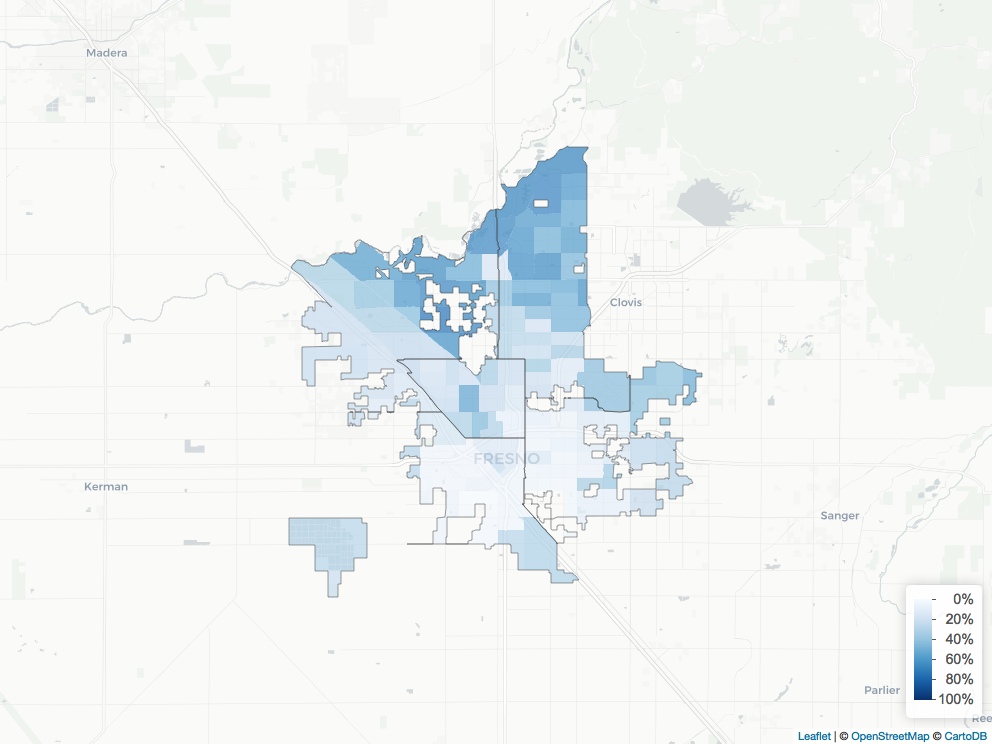

### Where white drivers are pulled over

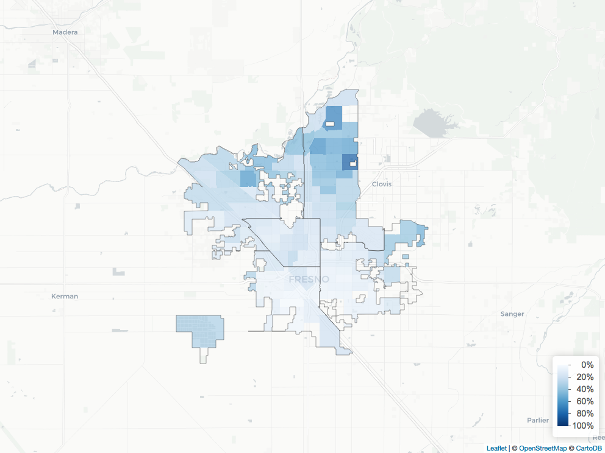

### Making more maps, for black and hispanic Fresnans

Running the same code as above, but doing it for black and hispanic population and drivers. We are also using htmlwidgets and mapview to save the maps in two ways: as interactive html pages and as images. In our web story, we juxtaposed the images, but the html pages provide interactivity, with tooltips that’ll tell users the number of stops and the racial makeup by census tract.

```r
### black

# creating color pal and pop up for black pop map
popup_black <- paste0("Census tract: ", race_stop_map$id, "<br>", "% of population that is black: ", race_stop_map$pc_black_population)
pal_black <- colorNumeric(
  palette = "Greens",
  domain = c(0,100), na.color = "transparent"
)

# mapping black population
black_pop_map <- leaflet(options = leafletOptions(zoomControl = FALSE)) %>%
  addProviderTiles("CartoDB.Positron") %>%
  addPolygons(data = race_stop_map,
              fillColor = ~pal_black(pc_black_population),
              color = "#b2aeae",
              fillOpacity = 0.7,
              weight = 0,
              smoothFactor = 0.2,
              popup = popup_black) %>%
  addPolylines(data = fpdBound_lines,
               color = "#3b3b3b", weight = 1, smoothFactor = 0.5)  %>%
  leaflet::addLegend("bottomright", pal = pal_black, values = c(0,100),
                     labFormat = labelFormat(suffix = "%"),
                     opacity = 1
  )

print(black_pop_map)

# saving map as html
htmlwidgets :: saveWidget(black_pop_map, "black_pop_map.html", selfcontained = TRUE, libdir = NULL, background = "white")

# saving screen shot of map for web juxtapose feature
mapshot(black_pop_map, file = paste0(getwd(), "/black_pop_map.png"))

# creating color pal and pop up for black stops map
popup_black_stops <- paste0("Census tract: ", race_stop_map$id, "<br>", "% of drivers stopped who were black: ", race_stop_map$pc_black_stops)
pal_black_stops <- colorNumeric(
  palette = "Greens",
  domain = c(0,100), na.color = "transparent"
)

# mapping stops of black drivers
black_stops_map <- leaflet(options = leafletOptions(zoomControl = FALSE)) %>%
  addProviderTiles("CartoDB.Positron") %>%
  addPolygons(data = race_stop_map,
              fillColor = ~pal_black_stops(pc_black_stops),
              color = "#b2aeae",
              fillOpacity = 0.7,
              weight = 0,
              smoothFactor = 0.2,
              popup = popup_black_stops) %>%
  addPolylines(data = fpdBound_lines,
               color = "#3b3b3b", weight = 1, smoothFactor = 0.5) %>%
  leaflet::addLegend("bottomright", pal = pal_black_stops, values = c(0,100),
                     labFormat = labelFormat(suffix = "%"),
                     opacity = 1
  )

print(black_stops_map)

# saving map as html
htmlwidgets :: saveWidget(black_stops_map, "black_stops_map.html", selfcontained = TRUE, libdir = NULL, background = "white")

# saving screen shot of map for web juxtapose feature

mapshot(black_stops_map, file = paste0(getwd(), "/black_stops_map.png"))

### hispanic

# creating color pal and pop up for hispanic pop map
popup_hispanic <- paste0("Census tract: ", race_stop_map$id, "<br>", "% of population that is Hispanic: ", race_stop_map$pc_hispanic_population)
pal_hispanic <- colorNumeric(
  palette = "Oranges",
  domain = c(0,100), na.color = "transparent"
)

# mapping Hispanic population
hispanic_pop_map <- leaflet(options = leafletOptions(zoomControl = FALSE)) %>%
  addProviderTiles("CartoDB.Positron") %>%
  addPolygons(data = race_stop_map,
              fillColor = ~pal_hispanic(pc_hispanic_population),
              color = "#b2aeae",
              fillOpacity = 0.7,
              weight = 0,
              smoothFactor = 0.2,
              popup = popup_hispanic) %>%
  addPolylines(data = fpdBound_lines,
               color = "#3b3b3b", weight = 1, smoothFactor = 0.5) %>%
  leaflet::addLegend("bottomright", pal = pal_hispanic, values = c(0,100),
                     labFormat = labelFormat(suffix = "%"),
                     opacity = 1
  )

print(hispanic_pop_map)

# saving map as html
htmlwidgets :: saveWidget(hispanic_pop_map, "hispanic_pop_map.html", selfcontained = TRUE, libdir = NULL, background = "white")

# saving screen shot of map for web juxtapose feature
mapshot(hispanic_pop_map, file = paste0(getwd(), "/hispanic_pop_map.png"))


# creating color pal and pop up for stops of Hispanic drivers
popup_hispanic_stops <- paste0("Census tract: ", race_stop_map$id, "<br>", "% of drivers stopped who were Hispanic: ", race_stop_map$pc_hispanic_stops)
pal_hispanic_stops <- colorNumeric(
  palette = "Oranges",
  domain = c(0,100), na.color = "transparent"
)

# mapping stops of Hispanic drivers

hispanic_stops_map <- leaflet(options = leafletOptions(zoomControl = FALSE)) %>%
  addProviderTiles("CartoDB.Positron") %>%
  addPolygons(data = race_stop_map,
              fillColor = ~pal_hispanic_stops(pc_hispanic_stops),
              color = "#b2aeae",
              fillOpacity = 0.7,
              weight = 0,
              smoothFactor = 0.2,
              popup = popup_hispanic_stops) %>%
  addPolylines(data = fpdBound_lines,
               color = "#3b3b3b", weight = 1, smoothFactor = 0.5) %>%
  leaflet::addLegend("bottomright", pal = pal_hispanic_stops, values = c(0,100),
                     labFormat = labelFormat(suffix = "%"),
                     opacity = 1
  )

print(hispanic_stops_map)

# saving map as html
htmlwidgets :: saveWidget(hispanic_stops_map, "hispanic_stops_map.html", selfcontained = TRUE, libdir = NULL, background = "white")

# saving screen shot of map for web juxtapose feature
mapshot(hispanic_stops_map, file = paste0(getwd(), "/hispanic_stops_map.png"))
```

### Making bar chart for traffic stops by police district

We’re interested in the distribution of traffic stops, by race, throughout the department’s five districts. Later, we compare our findings here to the department’s crime data to test the police chief’s assertion that the department is making more stops in the places that have a higher rate of violent crime.

```r
# creating bar charts

# first getting stops by race in every fpd district

by_district_stops <- over(stop_sp, fpdBound_ll)

by_district_stops <- by_district_stops %>%
  group_by(PD_AREA_NA) %>%
  summarise(total_stops=n()) %>%
  arrange(desc(total_stops))

by_district_stops_white <- over(white_stop_sp, fpdBound_ll)

by_district_stops_white <- by_district_stops_white %>%
  group_by(PD_AREA_NA) %>%
  summarise(white_stops=n()) %>%
  arrange(desc(white_stops))

by_district_stops <- left_join(by_district_stops, by_district_stops_white)

by_district_stops_black <- over(black_stop_sp, fpdBound_ll)

by_district_stops_black <- by_district_stops_black %>%
  group_by(PD_AREA_NA) %>%
  summarise(black_stops=n()) %>%
  arrange(desc(black_stops))

by_district_stops <- left_join(by_district_stops, by_district_stops_black)

by_district_stops_hispanic <- over(hispanic_stop_sp, fpdBound_ll)

by_district_stops_hispanic <- by_district_stops_hispanic %>%
  group_by(PD_AREA_NA) %>%
  summarise(hispanic_stops=n()) %>%
  arrange(desc(hispanic_stops))

by_district_stops <- left_join(by_district_stops, by_district_stops_hispanic)

by_district_stops_asian <- over(asian_stop_sp, fpdBound_ll)

by_district_stops_asian <- by_district_stops_asian %>%
  group_by(PD_AREA_NA) %>%
  summarise(asian_stops=n()) %>%
  arrange(desc(asian_stops))

by_district_stops <- left_join(by_district_stops, by_district_stops_asian)

# dropping stops that happened outside the pd districts
by_district_stops <- by_district_stops %>%
  filter(!is.na(PD_AREA_NA))

# now making a grouped bar chart for traffic stops by district

# setting x axis order

xform <- list(categoryorder = "array",
              categoryarray = c("SOUTHWEST",
                                "SOUTHEAST",
                                "CENTRAL",
                                "NORTHWEST",
                                "NORTHEAST"))

district_race_chart <- plot_ly(by_district_stops, x = ~PD_AREA_NA, y = ~white_stops, type = 'bar', name = 'white stops',
                               marker = list(color = 'rgba(33,113,181,0.5)',
                                             line = list(color = 'rgba(33,113,181,.1)',
                                                         width = .7))) %>%
  add_trace(y = ~hispanic_stops, name = 'hispanic stops',
            marker = list(color = 'rgba(241,105,19,0.5)',
                          line = list(color = 'rgba(241,105,19,1)',
                                      width = .7))) %>%
  add_trace(y = ~black_stops, name = 'black stops',
            marker = list(color = 'rgba(35,139,69,0.5)',
                          line = list(color = 'rgba(35,139,69,1)',
                                      width = .7))) %>%
  add_trace(y = ~asian_stops, name = 'asian stops',
            marker = list(color = 'rgba(203,24,29,0.5)',
                          line = list(color = 'rgba(203,24,29,1)',
                                      width = .7))) %>%
  layout(yaxis = list(title = 'Stops'),
         xaxis = list(title = 'Police District'),
         barmode = 'group') %>%
  config(displayModeBar = FALSE) %>%
  layout(xaxis = xform)

print(district_race_chart)

htmlwidgets :: saveWidget(district_race_chart, "district_race_chart.html", selfcontained = TRUE, libdir = NULL, background = "white")
```

[interactive chart not shown]

### How do traffic stops by district line up with crime by district?

The police department has explained its disproportional traffic stop numbers by saying they stop more people in areas with higher crime. We tested this and found that it doesn’t exactly hold up. We downloaded this crime data from [Socrata](https://moto.data.socrata.com/dataset/Fresno-Police-Department/c943-w8up), which used to partner with the department to host its data. A spokesperson for Socrata has confirmed the data’s authenticity.

```r
# reading FPD incident data
fpd_crime <- read_csv("fpdIncidents_1118.csv")

# looking at crime types
crime_type <- fpd_crime %>%
  group_by(incident_type_primary) %>%
  summarise(count = n())


# creating df for violent crimes, plus drug offenses and vice
vc_drug <- c("CAD: ASSAULT", "CAD: WEAPONS OFFENSES", "CAD: ROBBERY", "RMS: ASSAULT/FIREARM", "RMS: ASSAULT/OTHER DANGEROUS WEAPON",
             "RMS: DV-ASSAULT/HANDS/FISTS/FEET/ETC-INJURY", "RMS: ROBB/STRONG ARM-HWY/ST/ALLEY/ETC", "RMS: ASSAULT/KNIFE/CUT INST",
             "RMS: ROBB W/GUN-HWY/ST/ALLEY/ECT", "RMS: DV-ASSAULT/OTHER DANGEROUS WEAPON", "RMS: ASSAULT/HANDS/FISTS/FEET/ETC-INJURY",
             "CAD: HOMICIDE", "RMS: DV-ASSAULT/KNIFE/CUT INST", "RMS: ROBB/STRONG ARM-COMMERCIAL HOUSE", "RMS: ROBB W/GUN-COMMERICAL HOUSE",
             "RMS: ROBB W/KNIFE/CUT INST-HWY/ST/ALLEY/ETC", "RMS: ROBB/STRONG ARM-RESIDENTIAL", "RMS: ROBB W/GUN-RESIDENTIAL",
             "RMS: ROBB W/OTHER WEAP-HWY/ST/ALLEY/ETC", "RMS: MURDER & NON NEG HOMICIDE", "RMS: ROBB/STRONG ARM-MISC", "RMS: ROBB W/GUN-CONV-STORE",
             "RMS: DV-ASSAULT/FIREARM", "RMS: ROBB W/KNIFE/CUT INST-COMMERCIAL HOUSE", "RMS: ROBB/STRONG ARM-CONV STORE", "RMS: ROBB W/GUN-MISC",
             "RMS: ROBB W/OTHER WEAP-COMMERICAL HOUSE", "RMS: ROBB W/GUN-GAS/SERV STATION", "RMS: ROBB W/OTHER WEAP-MISC", "RMS: ROBB W/OTHER WEAP-RESIDENTIAL",
             "RMS: ROBB W/KNIFE/CUT INST-CONV STORE", "RMS: ROBB W/KNIFE/CUT INST-MISC", "RMS: ROBB W/OTHER WEAP-CONV STORE", "RMS: ROBB/STRONG ARM-GAS/SERV STATION",
             "RMS: ROBB W/KNIFE/CUT INST-RESIDENTIAL", "RMS: ROBB/STRONG ARM-BANK", "RMS: ROBB W/OTHER WEAP-GAS/SERV STATION", "RMS: ROBB W/GUN-BANK",
             "RMS: ROBB W/KNIFE/CUT INST-GAS/SERV STATION", "RMS: ROBB W/KNIFE/CUT INST-BANK", "CAD: NARCOTICS", "CAD: VICE CRIMES")

# creating dfs of only violent and drug crimes
fpd_crime_vc_drug <- fpd_crime %>%
  filter(incident_type_primary %in% vc_drug)

# calculating vc+drug in each police district

# We only need the columns with the latitude and longitude
fpd_crime_vc_drug_coords <- fpd_crime_vc_drug[c("longitude", "latitude")]

# Making sure we are working with rows that don't have any blanks
fpd_crime_vc_drug_coords <- fpd_crime_vc_drug_coords[complete.cases(fpd_crime_vc_drug_coords),]

# Letting R know that these are specifically spatial coordinates
fpd_crime_vc_drug_sp <- SpatialPoints(fpd_crime_vc_drug_coords)

# Applying projections to the coordinates so they match up with the shapefile we're joining them with
# More projections information http://trac.osgeo.org/proj/wiki/GenParms
proj4string(fpd_crime_vc_drug_sp) <- "+proj=longlat +datum=NAD83 +no_defs +ellps=GRS80 +towgs84=0,0,0"

vc_drug_by_district <- over(fpd_crime_vc_drug_sp, fpdBound_ll)

vc_drug_by_district <- vc_drug_by_district %>%
  group_by(PD_AREA_NA) %>%
  summarise(vc_drug_total=n()) %>%
  arrange(desc(vc_drug_total))

vc_drug_by_district <- vc_drug_by_district %>%
  mutate(vc_drug_freq = vc_drug_total/sum(vc_drug_total)*100)

datatable(vc_drug_by_district, rownames = FALSE, colnames = c("police district", "total violent and drug crimes", "percent of violent and drug crimes"))
```

| police district | total violent and drug crimes | percent of violent and drug crimes |
| --- | --- | --- |
| SOUTHEAST | 25483 | 24.4701792796167 |
| SOUTHWEST | 23149 | 22.2289440075284 |
| CENTRAL | 22846 | 21.9379867292753 |
| NORTHEAST | 15890 | 15.2584526450225 |
| NORTHWEST | 14439 | 13.8651225765563 |
|  | 2332 | 2.23931476200079 |

### Making charts for search and arrest rates

We know disparity exists in who gets stopped — but what about when the interaction gets more serious? We found the disparity increases. The charts below show the rates of car searches and drivers arrested by race.

```r
# making charts for search and arrest rates by race

# first, making a df for searches by race
searches_race <- tstops %>%
  filter(VEHICLE_SEARCHED == "Y") %>%
  group_by(APPARENT_RACE) %>%
  summarise(total_searches=n()) %>%
  arrange(desc(total_searches))

# renaming variables, spelling out race names
searches_race[1, "APPARENT_RACE"] <- "hispanic"
searches_race[2, "APPARENT_RACE"] <- "black"
searches_race[3, "APPARENT_RACE"] <- "white"
searches_race[4, "APPARENT_RACE"] <- "asian"
searches_race[5, "APPARENT_RACE"] <- "other"

searches_race <- left_join(searches_race, stops_race)

searches_race <- searches_race %>%
  mutate(search_rate = round(total_searches/total_stops*1000,2))

# dropping "other" searches
searches_race <- searches_race %>%
  filter(APPARENT_RACE != "other")

# dropping "other" searches
searches_race <- searches_race %>%
  filter(APPARENT_RACE != "other")

# renaming race col
names(searches_race)[1]<-"race"

search_rate_chart <- plot_ly(searches_race, x = ~search_rate, y = ~race, type = 'bar',
                             marker = list(color = 'rgba(37,37,37,0.5)',
                                           line = list(color = 'rgba(37,37,37,1)',
                                                       width = .7))) %>%
  layout(xaxis = list(title = "Rate of car searches (per 1,000 traffic stops)"),
         yaxis = list(title ="")) %>%
  config(displayModeBar = FALSE)


print(search_rate_chart)

# saving as html page
htmlwidgets :: saveWidget(search_rate_chart, "search_rate_chart.html", selfcontained = TRUE, libdir = NULL, background = "white")
```

[interactive chart not shown]

```r
# now, making a df for arrests by race
arrests_race <- tstops %>%
  filter(ACTION_TAKEN == "A") %>%
  group_by(APPARENT_RACE) %>%
  summarise(total_arrests=n()) %>%
  arrange(desc(total_arrests))

# renaming variables, spelling out race names
arrests_race[1, "APPARENT_RACE"] <- "hispanic"
arrests_race[2, "APPARENT_RACE"] <- "black"
arrests_race[3, "APPARENT_RACE"] <- "white"
arrests_race[4, "APPARENT_RACE"] <- "asian"
arrests_race[5, "APPARENT_RACE"] <- "other"

arrests_race <- left_join(arrests_race, stops_race)

arrests_race <- arrests_race %>%
  mutate(arrest_rate = round(total_arrests/total_stops*1000,2))


# dropping "other" arrests
arrests_race <- arrests_race %>%
  filter(APPARENT_RACE != "other")

# renaming race col
names(arrests_race)[1]<-"race"

arrest_rate_chart <- plot_ly(arrests_race, x = ~arrest_rate, y = ~race, type = 'bar',
                             marker = list(color = 'rgba(37,37,37,0.5)',
                                           line = list(color = 'rgba(37,37,37,1)',
                                                       width = .7))) %>%
  layout(xaxis = list(title = "Rate of drivers arrested (per 1,000 traffic stops)"),
         yaxis = list(title ="")) %>%
  config(displayModeBar = FALSE)


print(arrest_rate_chart)

# saving as html page
htmlwidgets :: saveWidget(arrest_rate_chart, "arrest_rate_chart.html", selfcontained = TRUE, libdir = NULL, background = "white")
```

[interactive chart not shown]

## **Looking at suspension and expulsions in local schools**

### Loading and processing the data

```r
# loading 16-17 suspension data
susp17 <- read_tsv("susp1617.txt")

# loading other years of suspension data
susp16 <- read_tsv("susp1516.txt")
susp15 <- read_tsv("susp1415.txt")
susp14 <- read_tsv("susp1314.txt")
susp13 <- read_tsv("susp1213.txt")
susp12 <- read_tsv("susp1112.txt")

# binding years
susp12_17 <- rbind(susp12,susp13,susp14,susp15,susp16,susp17)

# converting character columns to numeric
susp12_17$`Cumulative Enrollment` <- as.numeric(as.character(susp12_17$`Cumulative Enrollment`))
susp12_17$`Total Suspensions` <- as.numeric(as.character(susp12_17$`Total Suspensions`))
susp12_17$`Unduplicated Count of Students Suspended (Total)` <- as.numeric(as.character(susp12_17$`Unduplicated Count of Students Suspended (Total)`))
susp12_17$`Unduplicated Count of Students Suspended (Defiance-Only)` <- as.numeric(as.character(susp12_17$`Unduplicated Count of Students Suspended (Defiance-Only)`))
susp12_17$`Suspension Rate (Total)` <- as.numeric(as.character(susp12_17$`Suspension Rate (Total)`))
susp12_17$`Suspension Count Violent Incident (Injury)` <- as.numeric(as.character(susp12_17$`Suspension Count Violent Incident (Injury)`))
susp12_17$`Suspension Count Violent Incident (No Injury)` <- as.numeric(as.character(susp12_17$`Suspension Count Violent Incident (No Injury)`))
susp12_17$`Suspension Count Weapons Possession` <- as.numeric(as.character(susp12_17$`Suspension Count Weapons Possession`))
susp12_17$`Suspension Count Illicit Drug-Related` <- as.numeric(as.character(susp12_17$`Suspension Count Illicit Drug-Related`))
susp12_17$`Suspension Count of Students Suspended (Defiance-Only)` <- as.numeric(as.character(susp12_17$`Suspension Count of Students Suspended (Defiance-Only)`))
susp12_17$`Suspension Count Other Reasons` <- as.numeric(as.character(susp12_17$`Suspension Count Other Reasons`))

# adding a column for suspensions per 100 students, another way of measuring suspension rate
susp12_17 <- susp12_17 %>%
  mutate(susp_per_100students = round(susp12_17$'Total Suspensions'/susp12_17$'Cumulative Enrollment'*100,2))

# creating dfs for state and district levels
suspState <- susp12_17 %>%
  filter(`Aggregate Level`=="T")

suspDistrict <- susp12_17 %>%
  filter(`Aggregate Level`=="D1")

#creating df for race at each aggregate level
race <- c("RB","RI","RA","RF","RH","RD","RP","RT","RW")

suspStateRace <- suspState %>%
  filter(`Reporting Category` %in% race)

suspDistrictRace <- suspDistrict %>%
  filter(`Reporting Category` %in% race)

#looking at suspension rates by race for Fresno and Clovis USDs
suspDistrictRaceFresnoClovis <- suspDistrictRace %>%
  filter(`District Name` %in% c("Fresno Unified","Clovis Unified"))

#looking at suspension rates by race for Fresno USD only
suspDistrictRaceFresno <- suspDistrictRace %>%
  filter(`District Name` %in% c("Fresno Unified"))


### doing the above for expulsion data

# loading 16-17 expulsion data
exp17 <- read_tsv("exp1617.txt")

# loading other years of expulsion data
exp16 <- read_tsv("exp1516.txt")
exp15 <- read_tsv("exp1415.txt")
exp14 <- read_tsv("exp1314.txt")
exp13 <- read_tsv("exp1213.txt")
exp12 <- read_tsv("exp1112.txt")

exp12_17 <- rbind(exp12,exp13,exp14,exp15,exp16,exp17)

# converting character columns to numeric
exp12_17$`Cumulative Enrollment` <- as.numeric(as.character(exp12_17$`Cumulative Enrollment`))
exp12_17$`Total Expulsions` <- as.numeric(as.character(exp12_17$`Total Expulsions`))
exp12_17$`Unduplicated Count of Students Expelled (Total)` <- as.numeric(as.character(exp12_17$`Unduplicated Count of Students Expelled (Total)`))
exp12_17$`Unduplicated Count of Students Expelled (Defiance-Only)` <- as.numeric(as.character(exp12_17$`Unduplicated Count of Students Expelled (Defiance-Only)`))
exp12_17$`Expulsion Rate (Total)` <- as.numeric(as.character(exp12_17$`Expulsion Rate (Total)`))
exp12_17$`Expulsion Count Violent Incident (Injury)` <- as.numeric(as.character(exp12_17$`Expulsion Count Violent Incident (Injury)`))
exp12_17$`Expulsion Count Violent Incident (No Injury)` <- as.numeric(as.character(exp12_17$`Expulsion Count Violent Incident (No Injury)`))
exp12_17$`Expulsion Count Weapons Possession` <- as.numeric(as.character(exp12_17$`Expulsion Count Weapons Possession`))
exp12_17$`Expulsion Count Illicit Drug-Related` <- as.numeric(as.character(exp12_17$`Expulsion Count Illicit Drug-Related`))
exp12_17$`Expulsion Count of Students Expelled (Defiance-Only)` <- as.numeric(as.character(exp12_17$`Expulsion Count of Students Expelled (Defiance-Only)`))
exp12_17$`Expulsion Count Other Reasons` <- as.numeric(as.character(exp12_17$`Expulsion Count Other Reasons`))

# adding a column for expulsions per 100 students, another way of measuring Expulsion rate
exp12_17 <- exp12_17 %>%
  mutate(exp_per_100students = round(exp12_17$'Total Expulsions'/exp12_17$'Cumulative Enrollment'*100,2))

# creating dfs for state and district level
expState <- exp12_17 %>%
  filter(`Aggregate Level`=="T")

expDistrict <- exp12_17 %>%
  filter(`Aggregate Level`=="D1")

# creating df for race at each aggregate level
race <- c("RB","RI","RA","RF","RH","RD","RP","RT","RW")

expStateRace <- expState %>%
  filter(`Reporting Category` %in% race)

expDistrictRace <- expDistrict %>%
  filter(`Reporting Category` %in% race)

# looking at expulsion rates by race for Fresno and Clovis USDs
expDistrictRaceFresnoClovis <- expDistrictRace %>%
  filter(`District Name` %in% c("Fresno Unified","Clovis Unified"))

# looking at expulsion rates by race for Fresno USD only
expDistrictRaceFresno <- expDistrictRace %>%
  filter(`District Name` %in% c("Fresno Unified"))

# isolating suspensions and expulsions by race for the most recent school year and largest districts
district_50k <- c("Capistrano Unified", "Corona-Norco Unified", "Elk Grove Unified", "Fresno Unified", "Long Beach Unified", "Los Angeles Unified", "Oakland Unified", "San Bernardino City Unified", "San Diego Unified", "San Francisco Unified", "San Juan Unified", "Santa Ana Unified")

susp17DistrictRace <- suspDistrictRace %>%
  filter(`Academic Year` == "2016-17" & `District Name` %in% district_50k)

exp17DistrictRace <- expDistrictRace %>%
  filter(`Academic Year` == "2016-17" & `District Name` %in% district_50k)

# looking at total suspension and expulsion rates by district
suspDistrictTotal <- suspDistrict %>%
  filter(`Reporting Category` == "TA")

expDistrictTotal <- expDistrict %>%
  filter(`Reporting Category` == "TA")

# looking at same, for most recent year only and largest districts
susp17DistrictTotal <- suspDistrict %>%
  filter(`Reporting Category` == "TA" & `Academic Year` == "2016-17" & `Cumulative Enrollment` > 50000)

exp17DistrictTotal <- expDistrict %>%
  filter(`Reporting Category` == "TA" & `Academic Year` == "2016-17" & `Cumulative Enrollment` > 50000)


# looking at change over time of suspensions and expulsions by race in the largest school districts
suspLrgDistrictRace <- suspDistrictRace %>%
  filter(`District Name` %in% district_50k)

expLrgDistrictRace <- expDistrictRace %>%
  filter(`District Name` %in% district_50k)
```

### Charting suspension rates by race for FUSD schools

```r
# looking at suspension rates by race in FUSD
suspFUSD <- suspDistrictRace %>%
  filter(`District Name` == "Fresno Unified")

suspFUSD <- suspFUSD %>%
  filter(`Academic Year` == "2016-17")

# filtering out students who are not black, white, asian, hispanic
race_chart <- c("RB","RA","RH","RW")

suspFUSD <- suspFUSD %>%
  filter(`Reporting Category` %in% race_chart)

# making chart for suspension rate by race for FUSD

# renaming variables, spelling out race names
suspFUSD[1, "Reporting Category"] <- "asian"
suspFUSD[2, "Reporting Category"] <- "black"
suspFUSD[3, "Reporting Category"] <- "hispanic"
suspFUSD[4, "Reporting Category"] <- "white"

names(suspFUSD)[10]<-"race"

susp_rate_chart <- plot_ly(suspFUSD, x = ~susp_per_100students, y = ~race, type = 'bar',
                           marker = list(color = 'rgba(37,37,37,0.5)',
                                         line = list(color = 'rgba(37,37,37,1)',
                                                     width = .7))) %>%
  layout(xaxis = list(title = "Rate of suspensions (per 100 students)"),
         yaxis = list(title =""))%>%
  config(displayModeBar = FALSE)

print(susp_rate_chart)

# saving as html page
htmlwidgets :: saveWidget(susp_rate_chart, "susp_rate_chart.html", selfcontained = TRUE, libdir = NULL, background = "white")
```

[interactive chart not shown]

## **Looking at who’s locked up and how much their bail is**

Here we examine Fresno County jail booking and release data. (Note: much of this analysis is adapted from another project I worked on, found [here](https://github.com/reisthebault/adv_data_repo/tree/master).) The column in my data that contained the crimes each defendant was charged with and the bail amount associated with those crimes was pretty dirty — basically a string of text, numbers and symbols. We used OpenRefine and RegEx (code in aforementioned GitHub repo) to separate that column into columns that contained only the charge and only the bail amount.

```r
# load data
booking <- read_csv("fresnoBooking1718_clean.csv") %>%
  mutate(START_DATE = as.POSIXct(START_DATE, format = "%m/%d/%Y %I:%M:%S %p"),
         END_DATE = as.POSIXct(END_DATE, format = "%m/%d/%Y %I:%M:%S %p"),
         time_jailed2 = difftime(END_DATE,START_DATE, unit = "days"))

# converting bail amounts to numeric that read in as characters
booking$`bail 23` <- as.numeric(as.character(booking$`bail 23`))
booking$`bail 24` <- as.numeric(as.character(booking$`bail 24`))
booking$`bail 25` <- as.numeric(as.character(booking$`bail 25`))
booking$`bail 26` <- as.numeric(as.character(booking$`bail 26`))
booking$`bail 27` <- as.numeric(as.character(booking$`bail 27`))
booking$`bail 28` <- as.numeric(as.character(booking$`bail 28`))
booking$`bail 29` <- as.numeric(as.character(booking$`bail 29`))
booking$`bail 30` <- as.numeric(as.character(booking$`bail 30`))
booking$`bail 31` <- as.numeric(as.character(booking$`bail 31`))
booking$`bail 32` <- as.numeric(as.character(booking$`bail 32`))
booking$`bail 33` <- as.numeric(as.character(booking$`bail 33`))
booking$`bail 34` <- as.numeric(as.character(booking$`bail 34`))
booking$`bail 35` <- as.numeric(as.character(booking$`bail 35`))
booking$`bail 36` <- as.numeric(as.character(booking$`bail 36`))
```

### Which race is jailed most often?

Are all races in Fresno County locked up proportional to their shares of the population? Note the county’s demographics: 52 percent Hispanic, 31 percent white, 10 percent asian and 5 percent black. Below, we’ve found that black Fresnans are disproportionately jailed, three times their share of the county’s population. Later we’ll make a chart comparing these numbers.

```r
# race
race <- booking %>%
  group_by(RACE) %>%
  summarize(total_jailed = n()) %>%
  arrange(desc(total_jailed)) %>%
  mutate(pc_jailed = round(total_jailed/sum(total_jailed)*100,2))

datatable(race, rownames = FALSE, colnames = c("race", "count", "percent"), options = list(dom = "t"))
```

| race | count | percent |
| --- | --- | --- |
| HISPANIC | 19074 | 56.35 |
| WHITE | 8107 | 23.95 |
| BLACK | 4927 | 14.55 |
| ASIAN OR PACIFIC ISLANDER | 1020 | 3.01 |
| UNKNOWN | 285 | 0.84 |
| AMERICAN INDIAN OR ALASKAN NATIVE | 239 | 0.71 |
|  | 200 | 0.59 |

### How are people getting released?

People are released from jail for all sorts of reasons: their crime warranted only a citation, they paid bond, they qualified for a pre-trial supervision program, the jail was too crowded, etc. Which types of releases are most common? Note, the fifth-most popular release type is blank, which is because those people haven’t yet been released.

We see the plurality of inmates were released on “time served.” This means that they either served out their court-appointed sentence or, by the time their case made it to sentencing, the judge ruled they had already served enough jail time. Because of the sluggish pace of many cases, this happens frequently.

```r
# release types
release_types <- booking %>%
  group_by(RELEASE_TYPE) %>%
  summarize(count = n()) %>%
  arrange(desc(count)) %>%
  mutate(percent = round(count/sum(count)*100, 2))

datatable(release_types, rownames = FALSE, colnames = c("release type", "count", "percent"))
```

| release type | count | percent |
| --- | --- | --- |
| TIME SERVED | 6144 | 18.15 |
| BOND | 5262 | 15.54 |
| CITATION | 4178 | 12.34 |
| PROBATION RELEASE | 3700 | 10.93 |
|  | 2998 | 8.86 |
| RELEASED ENROUTE | 2542 | 7.51 |
| NO CHARGES FILED | 2049 | 6.05 |
| HOLD DROPPED | 1143 | 3.38 |
| RELEASED OWN RECOGNIZANCE | 958 | 2.83 |
| PAST TIME TO FILE | 833 | 2.46 |

[output cut: 25 more lines]

### Looking at types of release by race

We see here that black inmates are far less likely than white inmates to be released on “pre-trial supervision,” which is considered the more lenient alternative to the money bail system. Black inmates are also less likely than white inmates to be released on their “own recognizance,” which means an inmate is allowed to go home if they promise to appear for their court hearings.

```r
# release type by race
release_race <- booking %>%
  group_by(RELEASE_TYPE, RACE) %>%
  summarize(count = n()) %>%
  arrange(desc(count)) %>%
  mutate(percent = round(count/sum(count)*100,2))

datatable(release_race, rownames = FALSE, colnames = c("release type", "race", "count", "percent"))
```

| release type | race | count | percent |
| --- | --- | --- | --- |
| TIME SERVED | HISPANIC | 3506 | 57.06 |
| BOND | HISPANIC | 3054 | 58.04 |
| CITATION | HISPANIC | 2544 | 60.89 |
| PROBATION RELEASE | HISPANIC | 2085 | 56.35 |
|  | HISPANIC | 1587 | 52.94 |
| TIME SERVED | WHITE | 1480 | 24.09 |
| RELEASED ENROUTE | HISPANIC | 1424 | 56.02 |
| BOND | WHITE | 1223 | 23.24 |
| NO CHARGES FILED | HISPANIC | 1154 | 56.32 |
| CITATION | WHITE | 966 | 23.12 |

[output cut: 162 more lines]

### Time for a multiple linear regression

What factors influence the bail amount that the court assigns each defendant? To help answer this question, we do a multiple linear regression. Our output is a defendant’s total bail amount and our variables are race, age, and types of crimes they’ve been charged with.

But before we do that, we do a couple things. First, we figure out how many felonies and how many misdemeanors each defendant is charged with. Then, we add up all the bails associated with those charges to get a total bail amount for each defendant.

```r
# create columns for felonies and misdemeanors
booking <- booking %>%
  mutate(charges_1_m = ifelse(grepl("\\[M\\]", `charges 1_clean`)==TRUE,1,0),
         charges_1_f = ifelse(grepl("\\[F\\]", `charges 1_clean`)==TRUE,1,0),
         charges_2_m = ifelse(grepl("\\[M\\]", `charges 2_clean`)==TRUE,1,0),
         charges_2_f = ifelse(grepl("\\[F\\]", `charges 2_clean`)==TRUE,1,0),
         charges_3_m = ifelse(grepl("\\[M\\]", `charges 3_clean`)==TRUE,1,0),
         charges_3_f = ifelse(grepl("\\[F\\]", `charges 3_clean`)==TRUE,1,0),
         charges_4_m = ifelse(grepl("\\[M\\]", `charges 4_clean`)==TRUE,1,0),
         charges_4_f = ifelse(grepl("\\[F\\]", `charges 4_clean`)==TRUE,1,0),
         charges_5_m = ifelse(grepl("\\[M\\]", `charges 5_clean`)==TRUE,1,0),
         charges_5_f = ifelse(grepl("\\[F\\]", `charges 5_clean`)==TRUE,1,0),
         charges_6_m = ifelse(grepl("\\[M\\]", `charges 6_clean`)==TRUE,1,0),
         charges_6_f = ifelse(grepl("\\[F\\]", `charges 6_clean`)==TRUE,1,0),
         charges_7_m = ifelse(grepl("\\[M\\]", `charges 7_clean`)==TRUE,1,0),
         charges_7_f = ifelse(grepl("\\[F\\]", `charges 7_clean`)==TRUE,1,0),
         charges_8_m = ifelse(grepl("\\[M\\]", `charges 8_clean`)==TRUE,1,0),
         charges_8_f = ifelse(grepl("\\[F\\]", `charges 8_clean`)==TRUE,1,0),
         charges_9_m = ifelse(grepl("\\[M\\]", `charges 9_clean`)==TRUE,1,0),
         charges_9_f = ifelse(grepl("\\[F\\]", `charges 9_clean`)==TRUE,1,0),
         charges_10_m = ifelse(grepl("\\[M\\]", `charges 10_clean`)==TRUE,1,0),
         charges_10_f = ifelse(grepl("\\[F\\]", `charges 10_clean`)==TRUE,1,0),
         charges_11_m = ifelse(grepl("\\[M\\]", `charges 11_clean`)==TRUE,1,0),
         charges_11_f = ifelse(grepl("\\[F\\]", `charges 11_clean`)==TRUE,1,0),
         charges_12_m = ifelse(grepl("\\[M\\]", `charges 12_clean`)==TRUE,1,0),
         charges_12_f = ifelse(grepl("\\[F\\]", `charges 12_clean`)==TRUE,1,0),
         charges_13_m = ifelse(grepl("\\[M\\]", `charges 13_clean`)==TRUE,1,0),
         charges_13_f = ifelse(grepl("\\[F\\]", `charges 13_clean`)==TRUE,1,0),
         charges_14_m = ifelse(grepl("\\[M\\]", `charges 14_clean`)==TRUE,1,0),
         charges_14_f = ifelse(grepl("\\[F\\]", `charges 14_clean`)==TRUE,1,0),
         charges_15_m = ifelse(grepl("\\[M\\]", `charges 15_clean`)==TRUE,1,0),
         charges_15_f = ifelse(grepl("\\[F\\]", `charges 15_clean`)==TRUE,1,0),
         charges_16_m = ifelse(grepl("\\[M\\]", `charges 16_clean`)==TRUE,1,0),
         charges_16_f = ifelse(grepl("\\[F\\]", `charges 16_clean`)==TRUE,1,0),
         charges_17_m = ifelse(grepl("\\[M\\]", `charges 17_clean`)==TRUE,1,0),
         charges_17_f = ifelse(grepl("\\[F\\]", `charges 17_clean`)==TRUE,1,0),
         charges_18_m = ifelse(grepl("\\[M\\]", `charges 18_clean`)==TRUE,1,0),
         charges_18_f = ifelse(grepl("\\[F\\]", `charges 18_clean`)==TRUE,1,0),
         charges_19_m = ifelse(grepl("\\[M\\]", `charges 19_clean`)==TRUE,1,0),
         charges_19_f = ifelse(grepl("\\[F\\]", `charges 19_clean`)==TRUE,1,0),
         charges_20_m = ifelse(grepl("\\[M\\]", `charges 20_clean`)==TRUE,1,0),
         charges_20_f = ifelse(grepl("\\[F\\]", `charges 20_clean`)==TRUE,1,0),
         charges_21_m = ifelse(grepl("\\[M\\]", `charges 21_clean`)==TRUE,1,0),
         charges_21_f = ifelse(grepl("\\[F\\]", `charges 21_clean`)==TRUE,1,0),
         charges_22_m = ifelse(grepl("\\[M\\]", `charges 22_clean`)==TRUE,1,0),
         charges_22_f = ifelse(grepl("\\[F\\]", `charges 22_clean`)==TRUE,1,0),
         charges_23_m = ifelse(grepl("\\[M\\]", `charges 23_clean`)==TRUE,1,0),
         charges_23_f = ifelse(grepl("\\[F\\]", `charges 23_clean`)==TRUE,1,0),
         charges_24_m = ifelse(grepl("\\[M\\]", `charges 24_clean`)==TRUE,1,0),
         charges_24_f = ifelse(grepl("\\[F\\]", `charges 24_clean`)==TRUE,1,0),
         charges_25_m = ifelse(grepl("\\[M\\]", `charges 25_clean`)==TRUE,1,0),
         charges_25_f = ifelse(grepl("\\[F\\]", `charges 25_clean`)==TRUE,1,0),
         charges_26_m = ifelse(grepl("\\[M\\]", `charges 26_clean`)==TRUE,1,0),
         charges_26_f = ifelse(grepl("\\[F\\]", `charges 26_clean`)==TRUE,1,0),
         charges_27_m = ifelse(grepl("\\[M\\]", `charges 27_clean`)==TRUE,1,0),
         charges_27_f = ifelse(grepl("\\[F\\]", `charges 27_clean`)==TRUE,1,0),
         charges_28_m = ifelse(grepl("\\[M\\]", `charges 28_clean`)==TRUE,1,0),
         charges_28_f = ifelse(grepl("\\[F\\]", `charges 28_clean`)==TRUE,1,0),
         charges_29_m = ifelse(grepl("\\[M\\]", `charges 29_clean`)==TRUE,1,0),
         charges_29_f = ifelse(grepl("\\[F\\]", `charges 29_clean`)==TRUE,1,0),
         charges_30_m = ifelse(grepl("\\[M\\]", `charges 30_clean`)==TRUE,1,0),
         charges_30_f = ifelse(grepl("\\[F\\]", `charges 30_clean`)==TRUE,1,0),
         charges_31_m = ifelse(grepl("\\[M\\]", `charges 31_clean`)==TRUE,1,0),
         charges_31_f = ifelse(grepl("\\[F\\]", `charges 31_clean`)==TRUE,1,0),
         charges_32_m = ifelse(grepl("\\[M\\]", `charges 32_clean`)==TRUE,1,0),
         charges_32_f = ifelse(grepl("\\[F\\]", `charges 32_clean`)==TRUE,1,0),
         charges_33_m = ifelse(grepl("\\[M\\]", `charges 33_clean`)==TRUE,1,0),
         charges_33_f = ifelse(grepl("\\[F\\]", `charges 33_clean`)==TRUE,1,0),
         charges_34_m = ifelse(grepl("\\[M\\]", `charges 34_clean`)==TRUE,1,0),
         charges_34_f = ifelse(grepl("\\[F\\]", `charges 34_clean`)==TRUE,1,0),
         charges_35_m = ifelse(grepl("\\[M\\]", `charges 35_clean`)==TRUE,1,0),
         charges_35_f = ifelse(grepl("\\[F\\]", `charges 35_clean`)==TRUE,1,0),
         charges_36_m = ifelse(grepl("\\[M\\]", `charges 36_clean`)==TRUE,1,0),
         charges_36_f = ifelse(grepl("\\[F\\]", `charges 36_clean`)==TRUE,1,0))

# create columns for total misdemeanors and felonies, summing the above columns we just created
booking <- booking %>%
  mutate(total_m = charges_1_m + charges_2_m + charges_3_m + charges_4_m + charges_5_m +
           charges_6_m + charges_7_m + charges_8_m + charges_9_m + charges_10_m +
           charges_11_m + charges_12_m + charges_13_m + charges_14_m + charges_15_m +
           charges_16_m + charges_17_m + charges_18_m + charges_19_m + charges_20_m +
           charges_21_m + charges_22_m + charges_23_m + charges_24_m + charges_25_m +
           charges_26_m + charges_27_m + charges_28_m + charges_29_m + charges_30_m +
           charges_31_m + charges_32_m + charges_33_m + charges_34_m + charges_35_m +
           charges_36_m,
         total_f = charges_1_f + charges_2_f + charges_3_f + charges_4_f + charges_5_f +
           charges_6_f + charges_7_f + charges_8_f + charges_9_f + charges_10_f +
           charges_11_f + charges_12_f + charges_13_f + charges_14_f + charges_15_f +
           charges_16_f + charges_17_f + charges_18_f + charges_19_f + charges_20_f +
           charges_21_f + charges_22_f + charges_23_f + charges_24_f + charges_25_f +
           charges_26_f + charges_27_f + charges_28_f + charges_29_f + charges_30_f +
           charges_31_f + charges_32_f + charges_33_f + charges_34_f + charges_35_f +
           charges_36_f)


# create columns for total bail
booking <- booking %>%
  mutate(total_bail = rowSums(select(., contains("bail")), na.rm = TRUE))
```

### Coding race as a categorical variable

In order to use a categorical variable like race in our multiple linear regression, we need to code it as a factor.

```r
# creating a factor variable for race in order to use it in a linear regression
booking$race.f <- factor(booking$RACE)
is.factor(booking$race.f)

print(levels(booking$race.f))

booking$race.f = factor(booking$race.f,levels(booking$race.f)[c(6,3,4,2,1,5)])
```

### Looking at the distribution of the total bail amounts

To do a multiple linear regression, we need our output to be approximately normal. But, below, we see it’s obviously not.

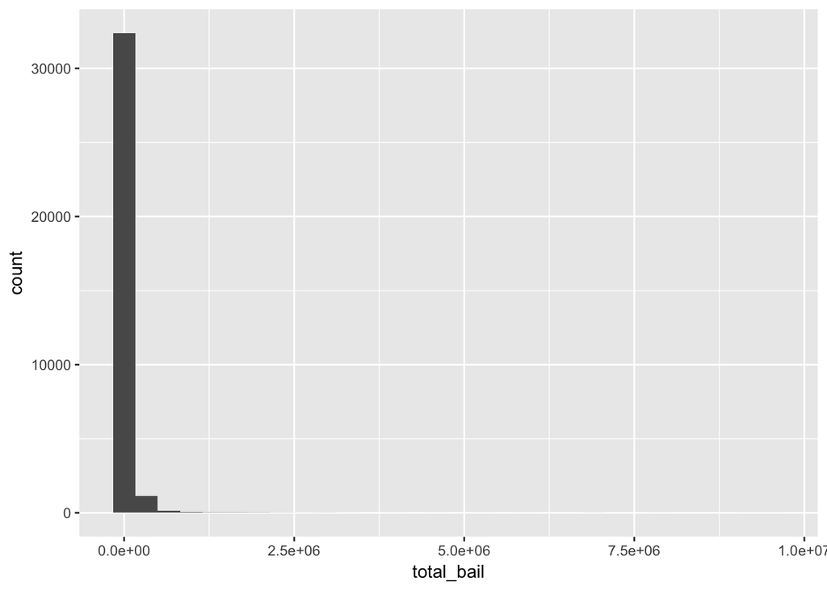

```r
# distribution of total bail
hist_total_bail <- ggplot(booking, aes(x=total_bail)) + geom_histogram()

plot(hist_total_bail)
```

### Transforming total bail column

In order to get an approximately normal distribution for total bail, we do a log10 transformation on the variable.

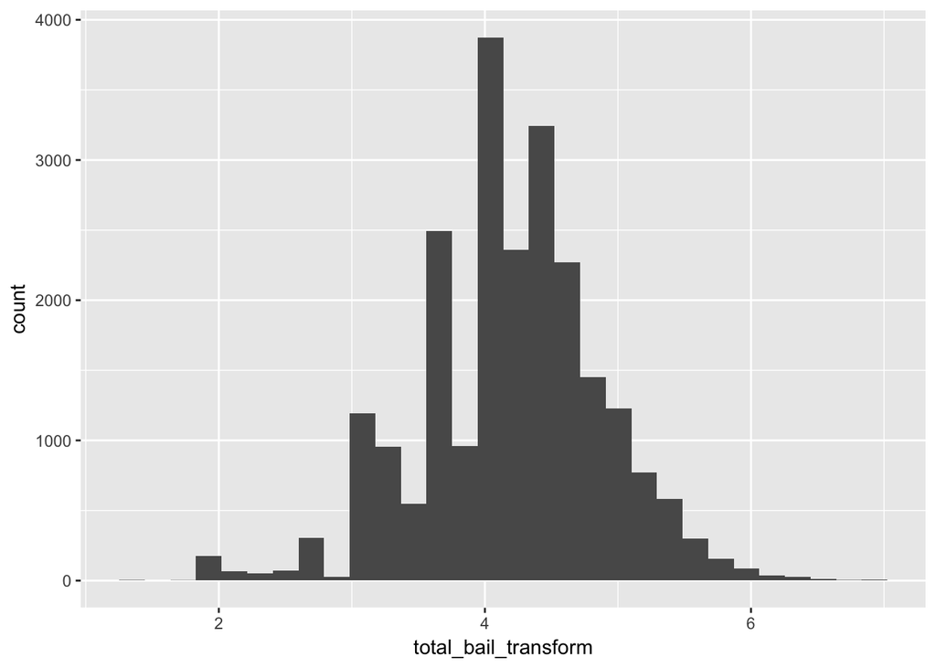

```r
# bail, our outcome variable, is highly skewed, so let's perform a transformation on the bail column and then drop the infinites values we've created
booking <- booking %>%
  mutate(total_bail_transform = log10(total_bail))

booking$total_bail_transform[which(is.infinite(booking$total_bail_transform))] = NA

# now, looking at distribution of transformed variable
hist_total_bail_transform <- ggplot(booking, aes(x=total_bail_transform)) + geom_histogram()

plot(hist_total_bail_transform)
```

### Building our model

First, there are some people charged with offenses that are not bailable. We don’t include them in our analysis as that’ll skew the outcome. Then, we built a model with the transformed total bail column as the outcome and race, age and crimes as the variables.

Our initial results show that this model explains about 30 percent of the variation in bail amounts (with an adjusted R-squared of 0.2976). But it also shows that six of our variables were statistically significant, including whether the defendant was black or hispanic, the defendant’s age, and the number of felonies and misdemeanors the defendant was charged with.

```r
# filter out those who weren't given bail
booking <- booking %>%
  mutate(no_bail = ifelse(grepl("NO BAIL", CHARGES)==TRUE,"NO BAIL","BAILABLE"))

booking_bailable <- booking %>%
  filter(no_bail == "BAILABLE")

# multiple linear regression
fit <- lm(total_bail_transform ~ race.f + total_m + total_f + AGE, data=booking_bailable)
summary(fit)
```

```
##
## Call:
## lm(formula = total_bail_transform ~ race.f + total_m + total_f +
##     AGE, data = booking_bailable)
##
## Residuals:
##     Min      1Q  Median      3Q     Max
## -5.4121 -0.2739  0.0091  0.2941  2.7264
##
## Coefficients:
##                                          Estimate Std. Error t value
## (Intercept)                             3.7897252  0.0169841 223.134
## race.fBLACK                             0.1642116  0.0140150  11.717
## race.fHISPANIC                          0.0725940  0.0100870   7.197
## race.fASIAN OR PACIFIC ISLANDER         0.0348311  0.0241721   1.441
## race.fAMERICAN INDIAN OR ALASKAN NATIVE 0.1403303  0.0547849   2.561
## race.fUNKNOWN                           0.0047831  0.0384644   0.124
## total_m                                 0.0553227  0.0030697  18.022
## total_f                                 0.2796400  0.0033540  83.374
## AGE                                     0.0022395  0.0003711   6.034
##                                         Pr(>|t|)
## (Intercept)                              < 2e-16 ***
## race.fBLACK                              < 2e-16 ***
## race.fHISPANIC                          6.42e-13 ***
## race.fASIAN OR PACIFIC ISLANDER           0.1496
## race.fAMERICAN INDIAN OR ALASKAN NATIVE   0.0104 *
## race.fUNKNOWN                             0.9010
## total_m                                  < 2e-16 ***
## total_f                                  < 2e-16 ***
## AGE                                     1.63e-09 ***
## ---
## Signif. codes:  0 '***' 0.001 '**' 0.01 '*' 0.05 '.' 0.1 ' ' 1
##
## Residual standard error: 0.5331 on 16969 degrees of freedom
##   (5004 observations deleted due to missingness)
## Multiple R-squared:  0.2979, Adjusted R-squared:  0.2976
## F-statistic: 899.9 on 8 and 16969 DF,  p-value: < 2.2e-16
```

### Testing the model

We came up with a model, so now we want to make sure we haven’t overfit it. To check this, we sample the original data set and create test and training datasets, then try our model on them.

```r
# now creating a training and test data set to test my model

train_idx <- sample(1:nrow(booking_bailable),10991,replace=FALSE)
booking_bailable_training <- booking_bailable[train_idx,] # selecting all these rows
booking_bailable_test <- booking_bailable[-train_idx,] # selecting all but these rows

# testing fit on training and test data

fit_training <- lm(total_bail_transform ~ race.f + total_m + total_f + AGE, data=booking_bailable_training)
summary(fit_training)
```

```
##
## Call:
## lm(formula = total_bail_transform ~ race.f + total_m + total_f +
##     AGE, data = booking_bailable_training)
##
## Residuals:
##     Min      1Q  Median      3Q     Max
## -3.4402 -0.2722  0.0059  0.2944  2.7224
##
## Coefficients:
##                                          Estimate Std. Error t value
## (Intercept)                             3.7799703  0.0235600 160.440
## race.fBLACK                             0.1698671  0.0192736   8.813
## race.fHISPANIC                          0.0737331  0.0139963   5.268
## race.fASIAN OR PACIFIC ISLANDER         0.0516975  0.0333091   1.552
## race.fAMERICAN INDIAN OR ALASKAN NATIVE 0.1045493  0.0829627   1.260
## race.fUNKNOWN                           0.0565864  0.0502519   1.126
## total_m                                 0.0552777  0.0041782  13.230
## total_f                                 0.2792540  0.0045702  61.103
## AGE                                     0.0024474  0.0005168   4.736
##                                         Pr(>|t|)
## (Intercept)                              < 2e-16 ***
## race.fBLACK                              < 2e-16 ***
## race.fHISPANIC                          1.41e-07 ***
## race.fASIAN OR PACIFIC ISLANDER            0.121
## race.fAMERICAN INDIAN OR ALASKAN NATIVE    0.208
## race.fUNKNOWN                              0.260
## total_m                                  < 2e-16 ***
## total_f                                  < 2e-16 ***
## AGE                                     2.22e-06 ***
## ---
## Signif. codes:  0 '***' 0.001 '**' 0.01 '*' 0.05 '.' 0.1 ' ' 1
##
## Residual standard error: 0.5259 on 8599 degrees of freedom
##   (2383 observations deleted due to missingness)
## Multiple R-squared:  0.3097, Adjusted R-squared:  0.309
## F-statistic: 482.1 on 8 and 8599 DF,  p-value: < 2.2e-16
```

```r
fit_test <- lm(total_bail_transform ~ race.f + total_m + total_f + AGE, data=booking_bailable_test)
summary(fit_test)
```

```
##
## Call:
## lm(formula = total_bail_transform ~ race.f + total_m + total_f +
##     AGE, data = booking_bailable_test)
##
## Residuals:
##     Min      1Q  Median      3Q     Max
## -5.4258 -0.2762  0.0119  0.2926  2.5100
##
## Coefficients:
##                                           Estimate Std. Error t value
## (Intercept)                              3.7993225  0.0245094 155.015
## race.fBLACK                              0.1583242  0.0204020   7.760
## race.fHISPANIC                           0.0714603  0.0145457   4.913
## race.fASIAN OR PACIFIC ISLANDER          0.0172325  0.0351067   0.491
## race.fAMERICAN INDIAN OR ALASKAN NATIVE  0.1650261  0.0732864   2.252
## race.fUNKNOWN                           -0.0639648  0.0595604  -1.074
## total_m                                  0.0554622  0.0045185  12.274
## total_f                                  0.2801338  0.0049358  56.756
## AGE                                      0.0020338  0.0005335   3.812
##                                         Pr(>|t|)
## (Intercept)                              < 2e-16 ***
## race.fBLACK                             9.48e-15 ***
## race.fHISPANIC                          9.15e-07 ***
## race.fASIAN OR PACIFIC ISLANDER         0.623538
## race.fAMERICAN INDIAN OR ALASKAN NATIVE 0.024361 *
## race.fUNKNOWN                           0.282877
## total_m                                  < 2e-16 ***
## total_f                                  < 2e-16 ***
## AGE                                     0.000139 ***
## ---
## Signif. codes:  0 '***' 0.001 '**' 0.01 '*' 0.05 '.' 0.1 ' ' 1
##
## Residual standard error: 0.5405 on 8361 degrees of freedom
##   (2621 observations deleted due to missingness)
## Multiple R-squared:  0.2862, Adjusted R-squared:  0.2855
## F-statistic:   419 on 8 and 8361 DF,  p-value: < 2.2e-16
```

### Making a chart comparing the jail’s population to the county’s

```r
# making bar chart for jail pop v county pop

# joining county demographic data to stop data
county_pop <- read_csv("demographics_fresnoCounty.csv")

# renaming variables, spelling race names lower case
race[1, "RACE"] <- "hispanic"
race[2, "RACE"] <- "white"
race[3, "RACE"] <- "black"
race[4, "RACE"] <- "asian"

pop_jail <- left_join(county_pop, race, by=c("race"="RACE"))

# setting x axis order
xform <- list(categoryorder = "array",
              categoryarray = c("white",
                                "hispanic",
                                "black",
                                "asian"))

pop_jail_chart <-  plot_ly(pop_jail, x = ~race, y = ~pc_county_pop, type = 'bar', name = '% of county pop.',
                           marker = list(color = 'rgba(189,189,189,0.5)',
                                         line = list(color = 'rgba(189,189,189,.1)',
                                                     width = .7))) %>%
  add_trace(y = ~pc_jailed, name = '% of jail pop.',
            marker = list(color = 'rgba(37,37,37,0.5)',
                          line = list(color = 'rgba(37,37,37,1)',
                                      width = .7))) %>%
  layout(yaxis = list(title = 'Percent'),
         xaxis = list(title = 'Race'),
         barmode = 'group') %>%
  config(displayModeBar = FALSE) %>%
  layout(xaxis = xform)

print(pop_jail_chart)

# saving as html page
htmlwidgets :: saveWidget(pop_jail_chart, "pop_jail_chart.html", selfcontained = TRUE, libdir = NULL, background = "white")
```

[interactive chart not shown]

## **Acknowledgments**

Thank you to [Peter Aldhous](https://twitter.com/paldhous) for advice on this analysis and help with the code — both in and out of his classes — and to [Jeremy Rue](https://twitter.com/jrue) for help making these charts clear and effective.